# e-commerce-shipping-analysis_w_ML

E-Commerce Shipping Analysis

Exploratory Data Analysis of On-Time Delivery Performance

**Derek Eodice, MBA, MSc**

**Date:** December 27, 2025

# Introduction

The rapid expansion of global e-commerce has placed unprecedented pressure on logistics networks. Customers expect fast, accurate, and reliable delivery—often at low cost. For businesses operating at scale, even a small increase in delay rates can trigger customer dissatisfaction, negative reviews, and operational losses.

The goal of this analysis is to identify the key factors that influence whether an e-commerce shipment arrives on time. Using the Customer Analytics dataset, we will explore how product characteristics, shipping modes, warehouse operations, customer ratings, and transit durations interact to affect delivery performance.

This notebook will cover:

1. Data understanding and cleaning
2. Exploratory analysis of customer, product, and logistics variables
3. Relationship analysis between features and on-time delivery
4. Insights and actionable recommendations

Ultimately, our objective is not only to understand what drives late deliveries, but how businesses can mitigate risks and improve their logistics workflows.

### Dataset Questions

1. What was the Customer Rating? And was the product delivered on time?
2. Was the customer’s query answered?
3. For products with high importance, do they have the highest ratings or are they delivered on time?

# Data Import and Data Cleansing

Our first step is to import the data directly from Kaggle. We will use the kagglehub package to link our Jupyter Notebook directly to Kaggle and download from there. Once we have the data downloaded from Kaggle, we will import the dataset into our Jupyter Notebook using `read_csv` from Pandas.

```
Path to dataset files: C:\Users\derek\.cache\kagglehub\datasets\prachi13\customer-analytics\versions\1
Files in dataset directory:
.notebook
Train.csv
```

|  | ID | Warehouse_block | Mode_of_Shipment | Customer_care_calls | Customer_rating | Cost_of_the_Product | Prior_purchases | Product_importance | Gender | Discount_offered | Weight_in_gms | Reached.on.Time_Y.N |
| --- | --- | --- | --- | --- | --- | --- | --- | --- | --- | --- | --- | --- |
| 0 | 1 | D | Flight | 4 | 2 | 177 | 3 | low | F | 44 | 1233 | 1 |
| 1 | 2 | F | Flight | 4 | 5 | 216 | 2 | low | M | 59 | 3088 | 1 |
| 2 | 3 | A | Flight | 2 | 2 | 183 | 4 | low | M | 48 | 3374 | 1 |
| 3 | 4 | B | Flight | 3 | 3 | 176 | 4 | medium | M | 10 | 1177 | 1 |
| 4 | 5 | C | Flight | 2 | 2 | 184 | 3 | medium | F | 46 | 2484 | 1 |

```
ID                      int64
Warehouse_block        object
Mode_of_Shipment       object
Customer_care_calls     int64
Customer_rating         int64
Cost_of_the_Product     int64
Prior_purchases         int64
Product_importance     object
Gender                 object
Discount_offered        int64
Weight_in_gms           int64
Reached.on.Time_Y.N     int64
dtype: object
(10999, 12)

Warehouse_block
F    3666
D    1834
A    1833
B    1833
C    1833
Name: count, dtype: int64

Mode_of_Shipment
Ship      7462
Flight    1777
Road      1760
Name: count, dtype: int64

count    10999.00
mean         4.05
std          1.14
min          2.00
25%          3.00
50%          4.00
75%          5.00
max          7.00
Name: Customer_care_calls, dtype: float64

count    10999.00
```

[output cut: 44 more lines]

```
25%          4.00
50%          7.00
75%         10.00
max         65.00
Name: Discount_offered, dtype: float64

count    10999.00
mean      3634.02
std       1635.38
min       1001.00
25%       1839.50
50%       4149.00
75%       5050.00
max       7846.00
Name: Weight_in_gms, dtype: float64
```

Our initial analysis yielded a dataframe of types `object` and `int64` across all 12 columns. The data frame shape of (10999, 12) indicated no irregularities in the shape of the data frame itself. The test of data integrity for each column yielded no errors nor anomalies that could otherwise jeopardize further data analysis. Therefore, no further data cleansing is required prior to conducting exploratory data analysis (EDA).

# EDA

Now that we confirmed our data upload and data integrity (clean, structured data for analysis), we can begin our exploratory data analysis (hereon referred to as EDA). Our first step in this section is to segment the numeric data from the data frame for easier analysis. We will do this by creating a data frame titled `numeric` that selects the `int64` data type. We will then drop the ID column from our numeric data frame, as this will not yield noteworthy results. Our final step in this process is to perform summary statistics on the remaining numeric columns.

|  | Customer_care_calls | Customer_rating | Cost_of_the_Product | Prior_purchases | Discount_offered | Weight_in_gms | Reached.on.Time_Y.N |
| --- | --- | --- | --- | --- | --- | --- | --- |
| count | 10999.00 | 10999.00 | 10999.00 | 10999.00 | 10999.00 | 10999.00 | 10999.00 |
| mean | 4.05 | 2.99 | 210.20 | 3.57 | 13.37 | 3634.02 | 0.60 |
| std | 1.14 | 1.41 | 48.06 | 1.52 | 16.21 | 1635.38 | 0.49 |
| min | 2.00 | 1.00 | 96.00 | 2.00 | 1.00 | 1001.00 | 0.00 |
| 25% | 3.00 | 2.00 | 169.00 | 3.00 | 4.00 | 1839.50 | 0.00 |
| 50% | 4.00 | 3.00 | 214.00 | 3.00 | 7.00 | 4149.00 | 1.00 |
| 75% | 5.00 | 4.00 | 251.00 | 4.00 | 10.00 | 5050.00 | 1.00 |
| max | 7.00 | 5.00 | 310.00 | 10.00 | 65.00 | 7846.00 | 1.00 |

Understanding the end-to-end flow of cargo in the logistics industry is imperative for success. While this dataset does not include all steps of the shipping process, it does contain detailed information about the origin warehouses. Our dataset contains five warehouses for the 10,999 shipments in question. We will look at the total number of shipments and overall percentage of shipments from each warehouse as part of our EDA. We will do this by first creating a dataset called `warehouse_summary` by using the `groupby` function. Next, we will calculate the sum of all of the shipments and use this to create a column that calculates the percentage of shipments from each warehouse (`% of Total Shipments`).

|  | Warehouse_block | Warehouse Block Shipments | % of Total Shipments |
| --- | --- | --- | --- |
| 0 | A | 1833 | 16.67 |
| 1 | B | 1833 | 16.67 |
| 2 | C | 1833 | 16.67 |
| 3 | D | 1834 | 16.67 |
| 4 | F | 3666 | 33.33 |

**Warehouse and Dataframe Summaries**

**Customer and Shipment Summaries**

The average customer called 4 times about their shipment(s), rated their experience a 2.99 out of 5, and made 4 prior purchases. The average product cost $210.20, was discounted an average of 13.37%, and weighed an average of 3634.02 grams. With the understanding that 1 = 'No' and 0 = 'Yes', our mean value of 0.60 indicates that the majority of the shipments did not arrive on time.

Now that we have a clean dataset, the next step is to get a basic understanding of our data. We will start by gathering some summary statistics on the dataset as a whole, and some of the points of interest as outlined in the instructions on Kaggle.

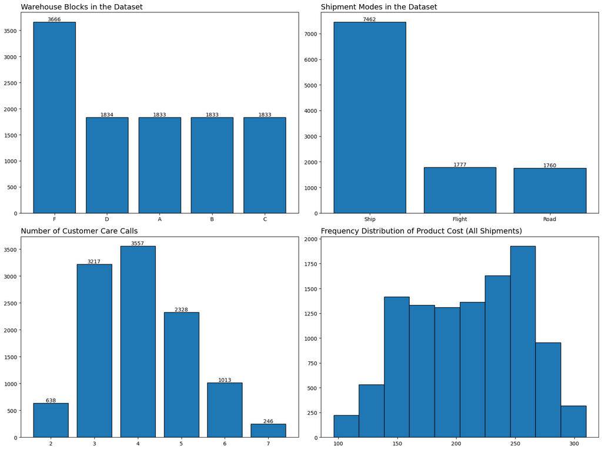

# Dataset Questions

## Question 1: Customer Rating and On-Time Delivery

The avearge customer service rating for the 10999 shipments in our dataset was 2.99. Out of the 10999 shipments, 4436 were delivered on time and 6563 were not delivered on time. This led to an on-time delivery rate of 40.33%. We can therefore confirm that most shipments were not delivered on time.

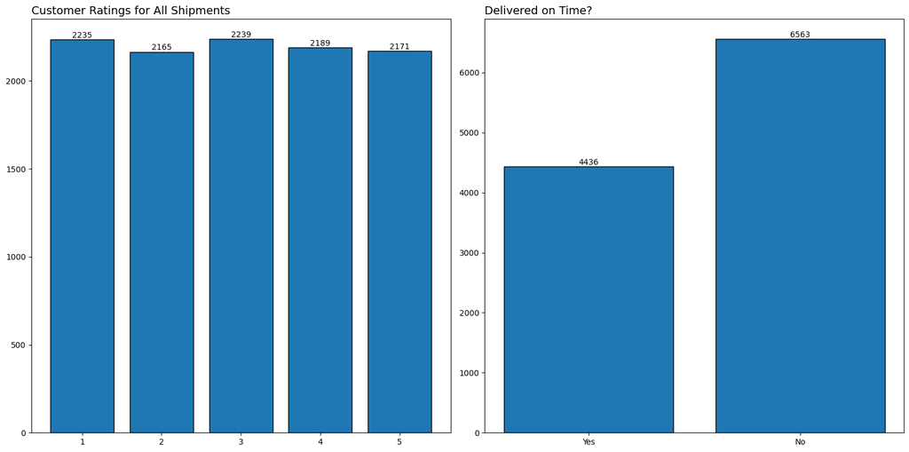

### A Deeper Dive - Are there variables that correlate well to either to `Customer_care_calls` or `Customer_rating`?

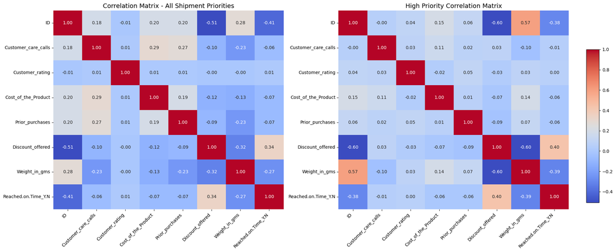

## Question 2: Do more customer care calls correlate with late deliveries or lower customer satisfaction?

One of the most critical scores in a competitive industry like logistics is the customer satisfaction score. Customers have a wide range of carriers depending on what they are shipping and to where they're shipping the item(s). Carriers in the third-party logistics (3PL) segment such as UPS, DHL and FedEx understand this and know that late shipments lead to a quick decline in customer satisfaction. To check the performance of the shipments in this dataset, we segmented the following variables from the above correlation plots for easier analysis.

- Customer_care_calls
- Reached.on.Time_Y.N
- Customer_rating

```
                     Customer_care_calls  Reached.on.Time_Y.N  Customer_rating
Customer_care_calls               1.0000              -0.0643           0.0119
Reached.on.Time_Y.N              -0.0643               1.0000           0.0131
Customer_rating                   0.0119               0.0131           1.0000
```

## Question 3: For products with high importance, do they have the highest ratings or are they delivered on time?

In the world of logistics, high priority means high stakes. In turn, high stakes create high rewards. One of the fastest ways for third party logistics (3PL) firms to create a competitive advantage is to deliver cargo ahead of schedule; especially in high priority situations. In our dataset's final question, we will examine if there is a difference in customer ratings or on-time delivery for high priority shipments. We will start this section by performing some analysis via scripting, then move on to data visualization and then conclude our findings. To make sure we are using only the high priority shipments, we will perform our analysis using the data frame titled `important` that we created earlier.

|  | Mode_of_Shipment | Shipment Mode Totals | % of Total Shipments |
| --- | --- | --- | --- |
| 0 | Flight | 163 | 17.19 |
| 1 | Road | 158 | 16.67 |
| 2 | Ship | 627 | 66.14 |

**High Priority Shipment Summaries**

There are 948 shipments classified as high priority in our data. The mode with the most amount of shipments was Ship, with a total of 627 (66.14)% of all high priority shipments. The mode with the least amount of shipments was Road, with a total of 158 (16.67)% of all high priority shipments.

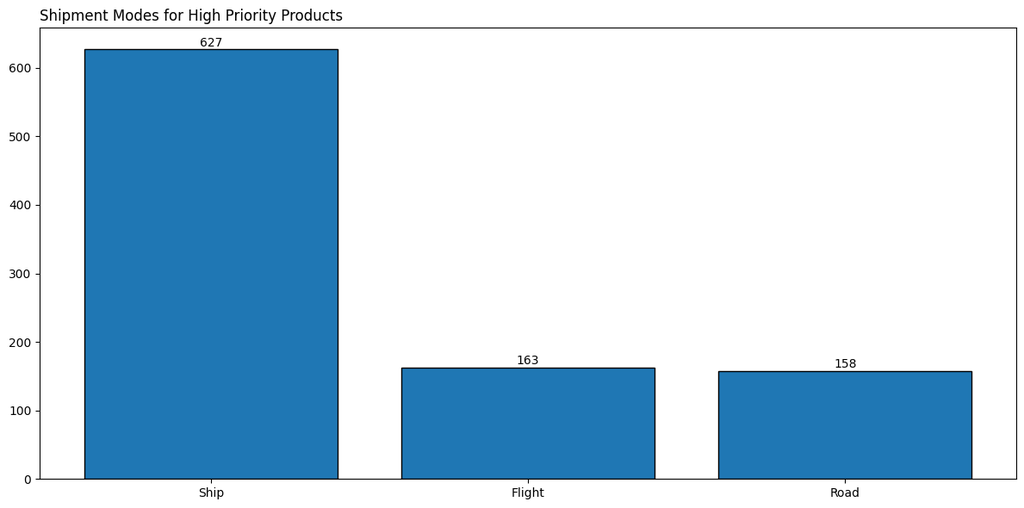

Our initial analysis of the high priority shipments shows that roughly two-thirds of said shipments in our dataset were shipped via ship. While it may seem odd that most of the shipments were shipped via ship, it's worth noting that over 80% of the world's freight is shipped through this mode as the main means of transport. It is worth noting that ocean freight often uses ground transportation via rail or truck to get the cargo to and from the port of embarkation (POE) or port of debarkation (POD). However, this dataset measures the main mode of transportation, vice auxiliary modes for first or final mile logistics. With this understanding, the next step is to visualize our dataset and see if high priority shipments have the highest rating/are delivered on time.

**High Priority Shipments vs. All Shipments - Descriptive Statistics**

**High Priority Shipments**

|  | Customer_care_calls | Customer_rating | Cost_of_the_Product | Prior_purchases | Discount_offered | Weight_in_gms | Reached.on.Time_Y.N |
| --- | --- | --- | --- | --- | --- | --- | --- |
| count | 948.00 | 948.00 | 948.00 | 948.00 | 948.00 | 948.00 | 948.00 |
| mean | 3.87 | 2.99 | 203.87 | 3.66 | 14.67 | 4005.55 | 0.65 |
| std | 1.05 | 1.41 | 46.70 | 1.97 | 17.34 | 1478.10 | 0.48 |
| min | 2.00 | 1.00 | 96.00 | 2.00 | 1.00 | 1007.00 | 0.00 |
| 25% | 3.00 | 2.00 | 165.00 | 2.00 | 4.00 | 2848.75 | 0.00 |
| 50% | 4.00 | 3.00 | 205.50 | 3.00 | 7.00 | 4408.00 | 1.00 |
| 75% | 5.00 | 4.00 | 243.00 | 4.00 | 18.00 | 5204.00 | 1.00 |
| max | 7.00 | 5.00 | 307.00 | 10.00 | 65.00 | 6000.00 | 1.00 |

**All Shipments**

|  | Customer_care_calls | Customer_rating | Cost_of_the_Product | Prior_purchases | Discount_offered | Weight_in_gms | Reached.on.Time_Y.N |
| --- | --- | --- | --- | --- | --- | --- | --- |
| count | 10999.00 | 10999.00 | 10999.00 | 10999.00 | 10999.00 | 10999.00 | 10999.00 |
| mean | 4.05 | 2.99 | 210.20 | 3.57 | 13.37 | 3634.02 | 0.60 |
| std | 1.14 | 1.41 | 48.06 | 1.52 | 16.21 | 1635.38 | 0.49 |
| min | 2.00 | 1.00 | 96.00 | 2.00 | 1.00 | 1001.00 | 0.00 |
| 25% | 3.00 | 2.00 | 169.00 | 3.00 | 4.00 | 1839.50 | 0.00 |
| 50% | 4.00 | 3.00 | 214.00 | 3.00 | 7.00 | 4149.00 | 1.00 |
| 75% | 5.00 | 4.00 | 251.00 | 4.00 | 10.00 | 5050.00 | 1.00 |
| max | 7.00 | 5.00 | 310.00 | 10.00 | 65.00 | 7846.00 | 1.00 |

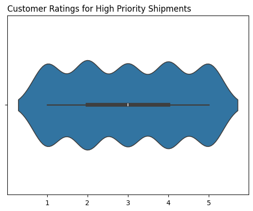

**Customer Service Metrics for High Priority Shipments**

The average customer service score for all shipments was **2.9905**, while high priority shipments averaged **2.9937**. This means high priority shipments scored **0.0031** points higher on average.

**Shipment Delivery Metrics for High Priority Shipments**

Out of **948** high priority shipments, **332** were delivered on time and **616** were delivered late.  
This results in an on-time delivery rate of **35.02%** for high priority shipments.

Across the full dataset of **10999** shipments, **4436** were delivered on time and **6563** were delivered late, producing an overall on-time rate of **40.33%**.

**High priority shipments were delivered on time 5.31% less often than the overall average.**

In answering the third question for the dataset, the answer is no. Yes, the high priority shipments scored wass 0.0031 better (on a scale of 0 to 5), which is low enough to be considered noise. Interestingly, the high priority shipments scored measurably lower in terms of on-time delivery when compared to all shipments. While speculative, there could be numerous reasons for this such as:

- Delays in customs clearance at the ports
- Difficulty in finding drivers to deliver the load
- Heavy seasonal volume at points along the chain

# Machine Learning

This section leverages machine learning to predict on-time delivery performance, building on insights from exploratory data analysis (EDA). The goal is to develop a robust model to proactively identify high-risk shipments, enabling operational interventions to improve customer satisfaction and reduce delays.

## Initial Preprocessing

Data preprocessing is critical to ensure model efficacy. The dataset was split into training (80%) and test (20%) sets, stratified by the target variable `Reached.on.Time_Y.N` to preserve class balance. Numerical features (e.g., `Customer_care_calls`, `Cost_of_the_Product`, `Weight_in_gms`) were standardized using `StandardScaler`, while categorical variables (e.g., `Warehouse_block`, `Mode_of_Shipment`) were one-hot encoded with `OneHotEncoder`. To address the imbalanced class distribution (60% late deliveries), SMOTE was applied to oversample the minority class (on-time deliveries) in the training set, resulting in balanced class counts post-resampling.

```
Shape of X_train: (8799, 11)
Shape of X_test: (2200, 11)
Shape of y_train: (8799,)
Shape of y_test: (2200,)
Class distribution after SMOTE: [5250 5250]
```

## Model Training and Hyperparameter Tuning

Four base models—LogisticRegression, RandomForest, XGBoost, and SVC—were evaluated, alongside a StackingClassifier combining RandomForest and XGBoost with a LogisticRegression final estimator. Hyperparameter tuning was performed using RandomizedSearchCV with 5-fold cross-validation, optimizing for F1 score to balance precision and recall given the business cost of false negatives (missed late deliveries). Key tuned parameters included:

- **LogisticRegression**: `C` (0.01–100), `solver` (liblinear, lbfgs)
- **RandomForest**: `n_estimators` (50–200), `max_depth` (None, 10–30)
- **XGBoost**: `n_estimators` (50–200), `max_depth` (3–7), `learning_rate` (0.01–0.2)
- **SVC**: `C` (0.1–10), `kernel` (linear, rbf), `gamma` (scale, auto)
- **StackingClassifier**: Tuned base model parameters and final estimator `C` (0.01–100)

The best models were saved for deployment, with hyperparameters yielding optimal F1 scores on the validation set.

```
Model: LogisticRegression
Best Parameters: {'solver': 'lbfgs', 'C': 0.01}
Validation F1 Score: 0.6341
Classification Report:
               precision    recall  f1-score   support

           0       0.54      0.86      0.66       887
           1       0.84      0.51      0.63      1313

    accuracy                           0.65      2200
   macro avg       0.69      0.68      0.65      2200
weighted avg       0.72      0.65      0.65      2200

Confusion Matrix:
 [[759 128]
 [644 669]]
ROC-AUC Score: 0.7231
```

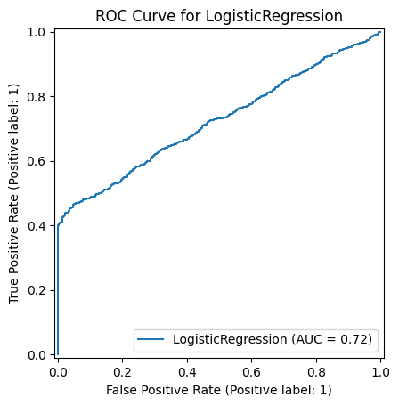

```
Model: RandomForest
Best Parameters: {'n_estimators': 200, 'min_samples_split': 2, 'min_samples_leaf': 1, 'max_depth': 30}
Validation F1 Score: 0.6755
Classification Report:
               precision    recall  f1-score   support

           0       0.56      0.78      0.65       887
           1       0.80      0.58      0.68      1313

    accuracy                           0.67      2200
   macro avg       0.68      0.68      0.66      2200
weighted avg       0.70      0.67      0.67      2200

Confusion Matrix:
 [[696 191]
 [546 767]]
ROC-AUC Score: 0.7345
```

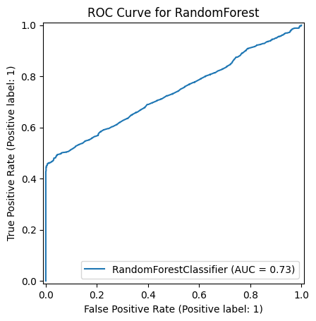

```
Model: XGBoost
Best Parameters: {'subsample': 1.0, 'n_estimators': 100, 'max_depth': 5, 'learning_rate': 0.2, 'colsample_bytree': 0.8}
Validation F1 Score: 0.6633
Classification Report:
               precision    recall  f1-score   support

           0       0.56      0.82      0.66       887
           1       0.82      0.56      0.66      1313

    accuracy                           0.66      2200
   macro avg       0.69      0.69      0.66      2200
weighted avg       0.71      0.66      0.66      2200

Confusion Matrix:
 [[725 162]
 [581 732]]
ROC-AUC Score: 0.7379
```

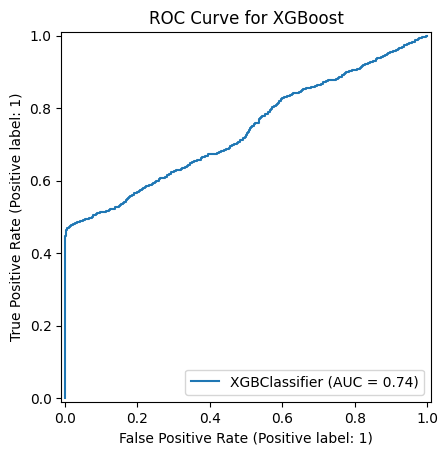

```
Model: SVC
Best Parameters: {'kernel': 'rbf', 'gamma': 'scale', 'C': 10}
Validation F1 Score: 0.6508
Classification Report:
               precision    recall  f1-score   support

           0       0.55      0.89      0.68       887
           1       0.87      0.52      0.65      1313

    accuracy                           0.67      2200
   macro avg       0.71      0.70      0.67      2200
weighted avg       0.74      0.67      0.66      2200

Confusion Matrix:
 [[786 101]
 [631 682]]

Model: StackingClassifier
Best Parameters: {'xgb__n_estimators': 200, 'xgb__max_depth': 5, 'xgb__learning_rate': 0.2, 'rf__n_estimators': 50, 'rf__max_depth': None, 'final_estimator__solver': 'lbfgs', 'final_estimator__C': 1}
Validation F1 Score: 0.6806
Classification Report:
               precision    recall  f1-score   support

           0       0.55      0.70      0.62       887
           1       0.75      0.62      0.68      1313

    accuracy                           0.65      2200
   macro avg       0.65      0.66      0.65      2200
weighted avg       0.67      0.65      0.66      2200

Confusion Matrix:
 [[620 267]
 [498 815]]
ROC-AUC Score: 0.7323
```

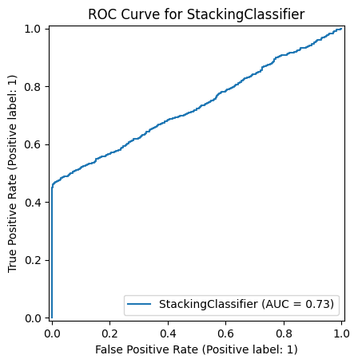

```
Best Model: StackingClassifier with F1 Score: 0.6806
Saved best model (StackingClassifier) to 'best_model.pkl'
```

## Model Evaluation and Comparison

Model performance was assessed on the held-out test set. Key metrics include:

- **LogisticRegression**: F1 Score = 0.6341, ROC-AUC = 0.7231
  - Best Parameters: `{'C': 0.01, 'solver': 'lbfgs'}`
  - Confusion Matrix: [[759 128], [644 669]]
- **RandomForest**: F1 Score = 0.6755, ROC-AUC = 0.7345
  - Best Parameters: `{'max_depth': 30, 'min_samples_leaf': 1, 'min_samples_split': 2, 'n_estimators': 200}`
  - Confusion Matrix: [[696 191], [546 767]]
- **XGBoost**: F1 Score = 0.6633, ROC-AUC = 0.7379
  - Best Parameters: `{'colsample_bytree': 0.8, 'learning_rate': 0.2, 'max_depth': 5, 'n_estimators': 100, 'subsample': 1.0}`
  - Confusion Matrix: [[725 162], [581 732]]
- **SVC**: F1 Score = 0.6508, ROC-AUC = N/A (no probability output)
  - Best Parameters: `{'C': 10, 'gamma': 'scale', 'kernel': 'rbf'}`
  - Confusion Matrix: [[786 101], [631 682]]
- **StackingClassifier**: F1 Score = 0.6806, ROC-AUC = 0.7323
  - Best Parameters: `{'final_estimator__C': 1, 'final_estimator__solver': 'lbfgs', 'rf__max_depth': None, 'rf__n_estimators': 50, 'xgb__learning_rate': 0.2, 'xgb__max_depth': 5, 'xgb__n_estimators': 200}`
  - Confusion Matrix: [[620 267], [498 815]]

The StackingClassifier emerged as the best model with an F1 score of 0.6806, indicating a balanced trade-off between identifying late deliveries (recall ~0.62) and minimizing false positives (precision ~0.75). Side-by-side confusion matrices visualize these results, highlighting model-specific strengths (e.g., SVC’s high true negatives).

## ROC Curves and Performance Metrics

ROC curves were generated for probabilistic models (LogisticRegression, RandomForest, XGBoost, StackingClassifier), with AUC scores ranging from 0.7231 to 0.7379. XGBoost achieved the highest AUC (0.7379), suggesting strong discriminatory power across probability thresholds. These curves, paired with F1 scores and confusion matrices, provide a comprehensive view of model performance, emphasizing the trade-off between sensitivity and specificity for flagging high-risk shipments.

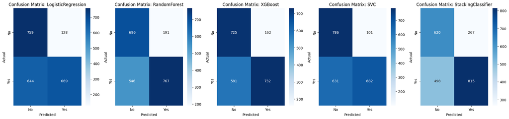

# Conclusion

This analysis of the Customer Analytics dataset provides a comprehensive view of e-commerce shipping performance, combining exploratory data analysis (EDA) with machine learning (ML) to uncover actionable insights.

## Future Work

Future enhancements include:

- Adding feature importance analysis (e.g., SHAP values) to pinpoint exact delay drivers.
- Expanding the dataset with real-time logistics data for dynamic forecasting.
- Testing ensemble models with neural networks or time-series approaches to capture temporal patterns in delays.